# Data analysis of developer responses

# Load data

```r
data <- read.csv( file = "./clus_data.csv", stringsAsFactors = FALSE )
numericColumns <- sapply(data, is.numeric)
```

```r
summary(as.data.frame(unclass(data)))
```

## Removing/marking outliers

The column JOBTIME has the values 9999 that would mess up some of the plots and statistics below.

```r
sum( data$JOBTIME > 200 , na.rm=T)
```

Turn values that too large into NA’s.

```r
data$JOBTIME <- ifelse( data$JOBTIME > 200, NA, data$JOBTIME)
```

# Mosaic plots

It is a good idea to visualize the conditional probabilities between different columns.

## Role vs gender

```r
mosaic( ROLE ~ gender, data = data, color=2:3, rot_labels=c(45,45,45,45)  )
```

[output not shown]

## Other trials

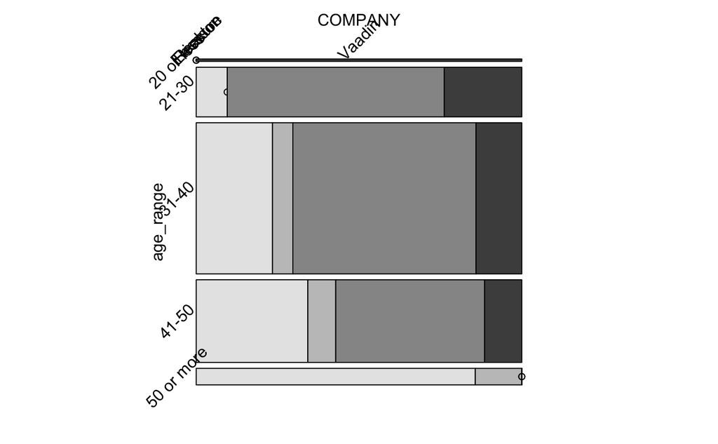

```r
mosaic( COMPANY ~ age_range, data = data, color=2:3, rot_labels=c(45,45,45,45)  )
```

## Role vs age

From the plots in this sub-section we can see:

- that there are no (interviewed) managers between 21-30;
- people older than 50 are much less likely to work in the industry (or answer interview questions);
- people older than 50 are much more likely to be managers, compared to the other age groups.

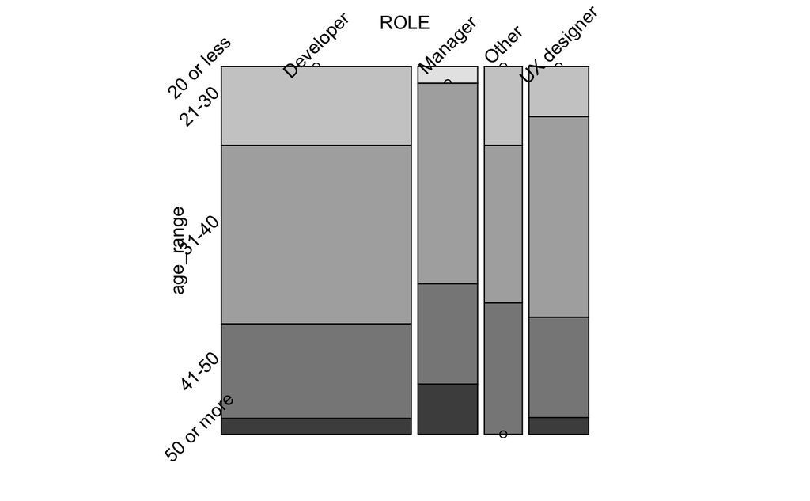

```r
mosaic( age_range ~ ROLE, data, direction = "v", rot_labels=c(45,45,45,45) )
```

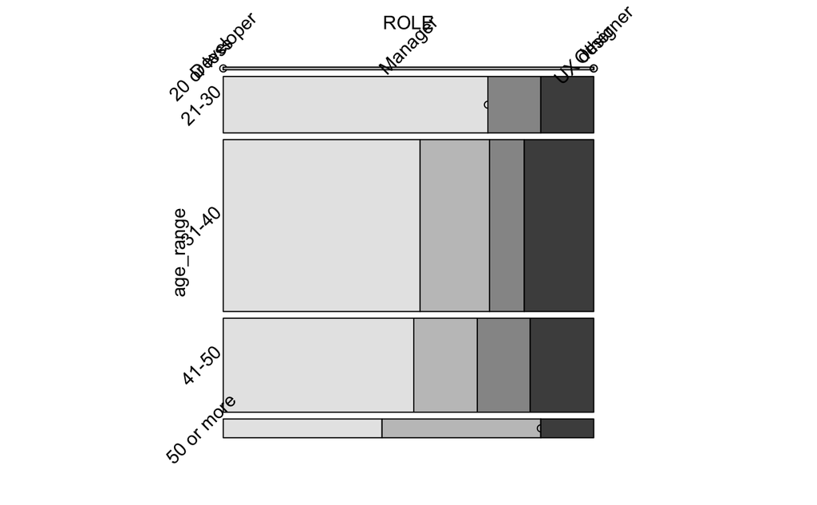

```r
mosaic( ROLE ~ age_range, data, rot_labels=c(45,45,45,45) )
```

# Clustering

Using hierarchical clustering and visualizing with a heat-map.

[interactive chart not shown]

### Correlations benween coliumns

Correlations for all numerical columns:

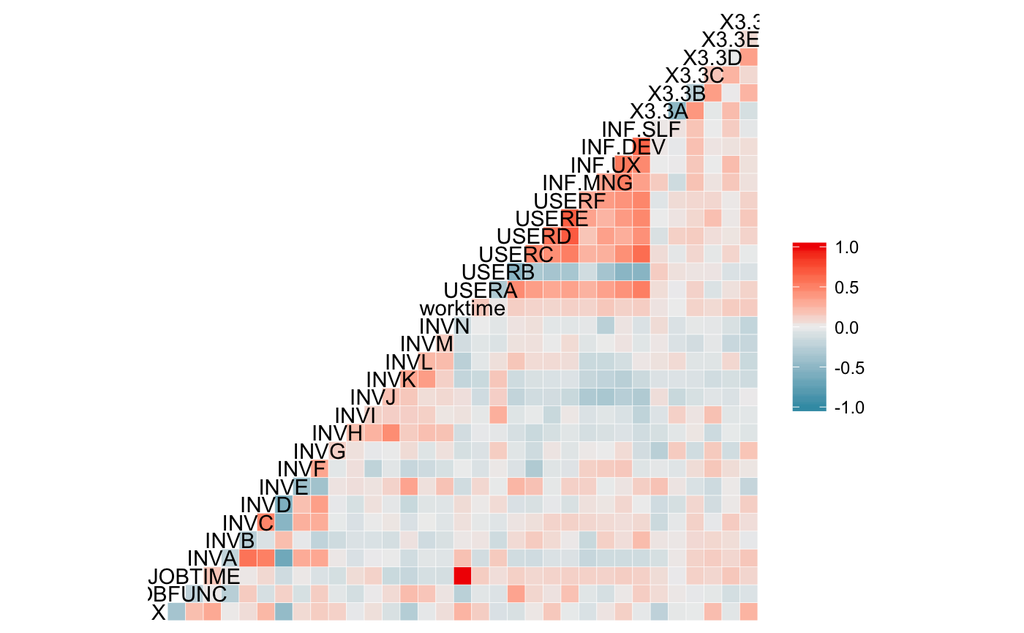

It is a good idea to explain the correlations that are close to 1 and -1. Do they make sense, etc.

Correlations for selected numerical columns:

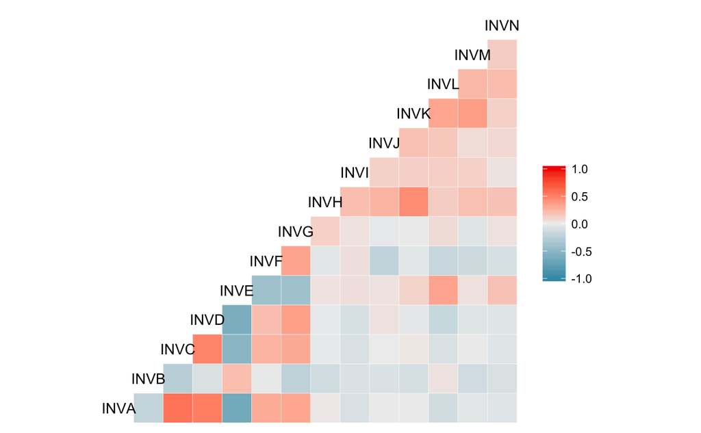